# Week 10: Power and Sample Size

Dr. Rajitha M. Silva

# Lecture Overview

This session introduces the core concepts of **Power and Sample Size** estimation in statistical testing, using real-world examples.

# Key Concepts

- **Effect Size**: The minimum size of the effect you hope to detect in a statistical test (e.g., a 20% improvement in click rates or a 10-run increase in powerplay).
- **Power**: The probability of detecting a given effect size with a given sample size. Typically, 0.80 (80%) is considered standard.
- **Significance Level ($\alpha$)**: The statistical significance level at which the test is conducted, usually set at 0.05.
- **Sample Size**: Number of observations required to detect an effect of a specified size with given power and significance.

To distinguish between a .350 hitter and a .200 hitter in baseball, not many at-bats are needed. But to distinguish between a .300 hitter and a .280 hitter, many more are required. The smaller the effect size, the larger the sample needed.

# Sports Example: Batting Averages

Suppose we want to distinguish between two cricket openers:

- Player A: Batting average = 35
- Player B: Batting average = 45
- pooled standard deviation = 10

What is the required sample size to detect this difference?

```r
effect_size <- (45 - 35) / 10  # Cohen's d
pwr.t.test(d = effect_size, sig.level = 0.05, power = 0.8, type = "two.sample")
```

```
##
##      Two-sample t test power calculation
##
##               n = 16.71472
##               d = 1
##       sig.level = 0.05
##           power = 0.8
##     alternative = two.sided
##
## NOTE: n is number in *each* group
```

# Simulation-Based Power Estimation: Powerplay Runs

You are a cricket data analyst evaluating two different batting strategies used during the Powerplay overs (the first 6 overs of a T20 match):

Strategy A (Conservative): Typically scores an average of 39 runs

Strategy B (Aggressive): Aims to score an average of 43 runs

The standard deviation of runs in both strategies is approximately 10

You want to know:

With a sample size of 30 matches per strategy, what is the probability (power) that a statistical test will detect a significant difference between the two strategies at a 5% significance level?

```r
simulate_power <- function(n, mean1, mean2, sd, reps = 1000, alpha = 0.05) {
  significant_results <- replicate(reps, {
    group1 <- rnorm(n, mean1, sd)       # Simulate n matches using Strategy A
    group2 <- rnorm(n, mean2, sd)       # Simulate n matches using Strategy B
    p_value <- t.test(group1, group2)$p.value  # Perform two-sample t-test
    p_value < alpha                     # Count as significant if p-value < alpha
  })
  mean(significant_results)            # Estimate power as proportion of significant results
}

simulate_power(n = 30, mean1 = 39, mean2 = 43, sd = 10)
```

```
## [1] 0.313
```

It simulates 1000 hypothetical experiments (by default) with:

```
30 matches per strategy

Strategy A has a true mean of 39

Strategy B has a true mean of 43

Standard deviation of 10 runs in both groups
```

For each experiment:

```
It generates synthetic match scores from normal distributions

Performs a two-sample t-test between the two strategies

Checks whether the test is statistically significant (i.e., p-value < 0.05)
```

It finally returns the estimated power: the proportion of times the null hypothesis was correctly rejected.

If you want to achieve 80% power, you’d need to increase the number of matches per group (sample size).

# Power Curve for Cricket Strategy

In statistical hypothesis testing, power increases with sample size. A Power Curve visually illustrates how different sample sizes affect the ability to detect a real difference (effect size) with a given significance level.

In this cricket example, we are comparing two powerplay strategies:

```
Strategy A (Conservative): Average = 39 runs

Strategy B (Aggressive): Average = 43 runs

Standard deviation (common): 10

Significance level $\alpha$ =0.05

Effect size = 4 runs
```

We want to explore how power changes as we increase the sample size (number of matches per group).

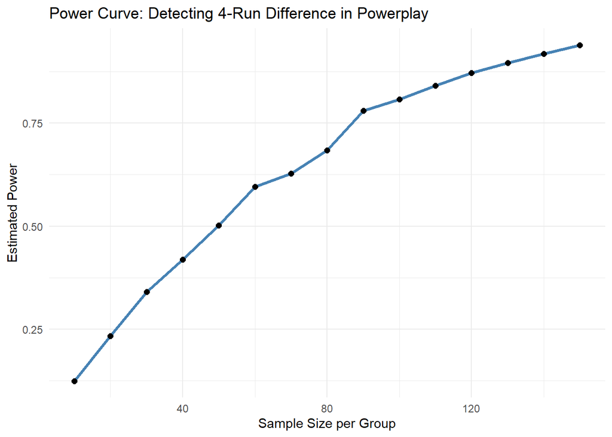

```r
# Power simulation function
simulate_power <- function(n, mean1, mean2, sd, reps = 1000, alpha = 0.05) {
  significant_results <- replicate(reps, {
    group1 <- rnorm(n, mean1, sd)
    group2 <- rnorm(n, mean2, sd)
    t.test(group1, group2)$p.value < alpha
  })
  mean(significant_results)
}

# Generate power curve
sample_sizes <- seq(10, 150, by = 10)
powers <- sapply(sample_sizes, simulate_power, mean1 = 39, mean2 = 43, sd = 10)
power_df <- data.frame(SampleSize = sample_sizes, Power = powers)

# Plot the power curve
ggplot(power_df, aes(x = SampleSize, y = Power)) +
  geom_line(color = "steelblue", size = 1.2) +
  geom_point(size = 2) +
  labs(title = "Power Curve: Detecting 4-Run Difference in Powerplay",
       x = "Sample Size per Group",
       y = "Estimated Power") +
  theme_minimal()
```

### Interpretation:

The curve shows that small sample sizes (e.g., 10-30 matches) are unlikely to detect the 4-run difference reliably.

Power increases as the sample size increases, approaching 1 as the sample becomes large.

You can use this curve to choose a sample size that ensures a target power level (commonly 0.80 or 80%).

This analysis supports practical decision-making: if the cost of running matches is high, you might only commit to a larger sample size if the detectable difference is worthwhile.

# Optional Exercise: Penalty Success Rate

A football analyst wants to test if a new technique improves penalty success from 75% to 85%.

```r
effect_size_penalty <- ES.h(p1 = 0.85, p2 = 0.75)
pwr.2p.test(h = effect_size_penalty, power = 0.9, sig.level = 0.05)
```

```
##
##      Difference of proportion power calculation for binomial distribution (arcsine transformation)
##
##               h = 0.2517987
##               n = 331.4508
##       sig.level = 0.05
##           power = 0.9
##     alternative = two.sided
##
## NOTE: same sample sizes
```

# Summary Table

| Feature | Effect Size | Sample Size |
| --- | --- | --- |
| What it measures | Strength of effect | Number of observations |
| Controlled by | Domain knowledge, practical goals | Design and cost constraints |
| Affects | Practical significance | Power and precision |
| In power analysis | Usually input | Usually calculated |

# Student Practical Assignment

1. Simulate a scenario comparing two T20 batting pairs.
2. Use both analytical and simulation-based methods to estimate power.
3. Plot a power curve varying the sample size.
4. Submit code and brief interpretation in RMarkdown or Jupyter Notebook.

# Supplementary Materials

To reinforce your understanding of **Power Analysis**, watch the following videos:

- [Power and Sample Size Calculation in Hypothesis Testing (StatQuest with Josh Starmer)](https://youtu.be/Rsc5znwR5FA?si=b_-a0MeL-Paoa-xA)
- [Statistical Power, The Concept and How to Calculate It (StatQuest with Josh Starmer)](https://youtu.be/VX_M3tIyiYk?si=wky3wpViwz_45b0R)

These offer intuitive explanations of how sample size, effect size, alpha level, and power interact in statistical tests.

### Power Estimation Using Permutation Test and Bootstrap Sampling

Traditional power analysis relies on theoretical distributions and assumptions (e.g., normality). When these assumptions may not hold, **resampling methods** such as **bootstrap** and **permutation tests** offer robust, data-driven alternatives for estimating statistical power.

These methods simulate repeated experiments to estimate how often a statistical test detects a true effect under given conditions.

#### Bootstrap-Based Power Estimation

**Bootstrap power estimation** involves:

1. Generating large synthetic populations with specified means and standard deviation.
2. Drawing bootstrap samples (with replacement) from each population.
3. Performing a t-test on each resampled pair.
4. Repeating the process many times and estimating the proportion of significant results.

```r
bootstrap_power <- function(n, mean1, mean2, sd, reps = 1000, alpha = 0.05) {
  true_group1 <- rnorm(10000, mean1, sd)
  true_group2 <- rnorm(10000, mean2, sd)

  significant <- replicate(reps, {
    sample1 <- sample(true_group1, n, replace = TRUE)
    sample2 <- sample(true_group2, n, replace = TRUE)
    t.test(sample1, sample2)$p.value < alpha
  })

  mean(significant)
}

# Example usage
bootstrap_power(n = 30, mean1 = 39, mean2 = 43, sd = 10)
```

```
## [1] 0.352
```

This code estimates the power of detecting a 4-run difference in cricket powerplay scores using bootstrap sampling with 30 matches per group.

#### Permutation Test-Based Power Estimation

**Permutation power estimation** involves:

1. Simulating two groups with known mean and standard deviation.
2. Performing a two-sample test on the observed data.
3. Creating a null distribution by randomly shuffling group labels.
4. Comparing the observed statistic to the permutation-based null distribution.
5. Repeating the entire experiment multiple times to estimate power.

```r
permutation_power <- function(n, mean1, mean2, sd, reps = 1000, permutations = 1000, alpha = 0.05) {
  power <- replicate(reps, {
    group1 <- rnorm(n, mean1, sd)
    group2 <- rnorm(n, mean2, sd)
    observed_diff <- mean(group2) - mean(group1)

    combined <- c(group1, group2)
    perm_diffs <- replicate(permutations, {
      shuffled <- sample(combined)
      mean(shuffled[(n+1):(2*n)]) - mean(shuffled[1:n])
    })

    p_value <- mean(abs(perm_diffs) >= abs(observed_diff))
    p_value < alpha
  })
  mean(power)
}

# Example usage
permutation_power(n = 30, mean1 = 39, mean2 = 43, sd = 10)
```

```
## [1] 0.33
```

This estimates the power of detecting a 4-run difference using a non-parametric permutation test.

#### Summary Table

| Scenario | Recommended Method |
| --- | --- |
| Normality assumed | Formula-based |
| Unknown or non-normal distributions | Bootstrap |
| Need for non-parametric inference | Permutation |

These simulation-based approaches are especially useful in data science and sports analytics where:

- Assumptions may not hold.
- Sample sizes are small.
- Data distributions are complex or unknown.
- You want to validate analytical power results.

Both methods provide **empirical power estimates** and can be adapted to real-world data situations for better planning of sample sizes.

## Practical Assignment: Power Analysis for Email Campaign Performance

### Objective

This hands-on assignment is designed to help you apply **power analysis** in a real-world digital marketing scenario. You will simulate data based on industry benchmarks, conduct power analysis using both formula-based and resampling methods, and determine the appropriate sample size for a conclusive A/B test.

### Real-World Scenario

A digital marketing team is running an **email A/B test** to compare the effectiveness of two subject lines in increasing the **email open rate**.

- **Subject Line A (Baseline)**: Current industry average open rate is 20% (0.20).
- **Subject Line B (New)**: The team hopes to improve this rate by at least 3% (i.e., up to 23%).
- **Each email costs money to send**, so determining the minimum required number of recipients per group is important before running the campaign.

You are tasked with:

### Tasks

#### Task 1: Calculate Sample Size Using Analytical Method

Use the `pwr.2p.test()` function to estimate the sample size needed to detect a 3% increase in open rates.

- What is the minimum number of emails needed per group?
- Repeat this analysis for effect sizes of 0.01 (1%) and 0.05 (5%). Summarize your results.

#### Task 2: Simulate Email Open Data and Estimate Power Using Bootstrap

- Try varying sample sizes (e.g., 100, 200, 500, 1000) and plot the power curve.

#### Task 3: Permutation Test-Based Power Estimation

- Repeat with different sample sizes and plot a power curve.

#### Task 4: Visualize Power Curve

Generate a power curve using either bootstrap or permutation results.

### Deliverables

Submit a report (in RMarkdown or HTML/PDF format) that includes:

1. Calculated sample sizes for various effect sizes.
2. Bootstrap and permutation-based power estimates.
3. Power curves and interpretation.